# An Introduction to Statistical Learning, Part 4: Logistic Regression

Steven Troxler

December 21, 2015

Welcome to the fourth post in my series on [An Introduction to Statistical Learning with Applications in R](http://www-bcf.usc.edu/~gareth/ISL/). In the [last post](http://www.steventroxler.com/blog/?p=44), we looked at the `lm` function in R and how we can use it for linear regression. This time, we’ll look a the related `glm` function, specifically for logistic regression.

## The `Smarket` dataset

We looked at the `Smarket` dataset in an earlier post.

```r
smarket <- tbl_df(ISLR::Smarket)
```

I’m a big fan of `ggplot2` as you know by now, but a handy built-in R function for looking at data is the `pairs` function, which makes a quick showing of all the variables’ two-way scatterplots:

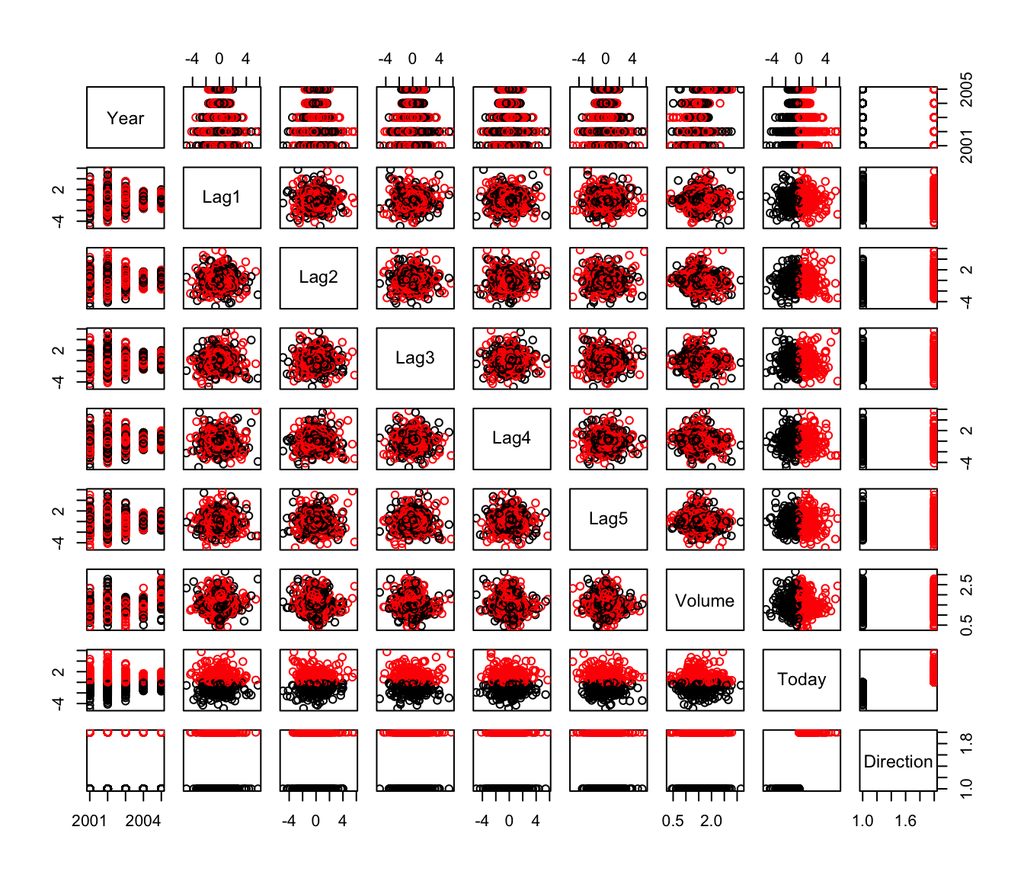

```r
pairs(smarket, col=smarket$Direction)
```

## Creating a logistic regression:

We run logistic regression as follows:

```r
model0 <- glm(
  Direction~Lag1 + Lag2 + Lag3 + Lag4 + Lag5 + Volume,
  data=smarket, family=binomial
)
```

The `family` input is important: the `glm` function in R fits *generalized linear models* which extend ideas from linear regression to general *exponential families*. Since our data is yes/no data, we tell the `glm` function that we want to use the `binomial` (or *Bernoulli*) distribution.

Let’s take a look at the model. We can use the `summary` function, as we did for linear models:

```r
summary(model0)
```

```
#>
#> Call:
#> glm(formula = Direction ~ Lag1 + Lag2 + Lag3 + Lag4 + Lag5 +
#>     Volume, family = binomial, data = smarket)
#>
#> Deviance Residuals:
#>    Min      1Q  Median      3Q     Max
#> -1.446  -1.203   1.065   1.145   1.326
#>
#> Coefficients:
#>              Estimate Std. Error z value Pr(>|z|)
#> (Intercept) -0.126000   0.240736  -0.523    0.601
#> Lag1        -0.073074   0.050167  -1.457    0.145
#> Lag2        -0.042301   0.050086  -0.845    0.398
#> Lag3         0.011085   0.049939   0.222    0.824
#> Lag4         0.009359   0.049974   0.187    0.851
#> Lag5         0.010313   0.049511   0.208    0.835
#> Volume       0.135441   0.158360   0.855    0.392
#>
#> (Dispersion parameter for binomial family taken to be 1)
#>
#>     Null deviance: 1731.2  on 1249  degrees of freedom
#> Residual deviance: 1727.6  on 1243  degrees of freedom
#> AIC: 1741.6
#>
#> Number of Fisher Scoring iterations: 3
```

The stock-market data shows low correlations between variables, which is typical of financial markets. Here we see that none of the coefficients in our model are statistically significant.

```r
fitted_probs <- predict(model0, type='response')
fitted_updown <- ifelse(fitted_probs > 0.5, "Up", "Down")
table(fitted_updown, smarket$Direction)
```

```
#>
#> fitted_updown Down  Up
#>          Down  145 141
#>          Up    457 507
```

Above, we used a new construct from R. The `ifelse` function takes a Boolean vector as its first argument, and returns a vector which has the second argument wherever the Boolean vector was `TRUE` and the third argument elsewhere.

We see that on the training data - where we hope to do fairly well - we still only get the right answer a bit more than half the time. Again, all evidence is that our model is at best weak, and at worst may just be fitting noise. We can also measure the empirical accuracy on the training set

```r
mean(fitted_updown == smarket$Direction)
```

```
#> [1] 0.5216
```

So on the training set we do a little better than 50-50. But the model is perfectly optimized on the training data, so we know it is fitting at least some noise. We next turn our attention to a more interesting question: is our model able to predict the future?

## Dividing data int training and test sets

In a situation like this, where the validity of our model is very much in doubt, it’s often a good idea to split the data into a *training set* and a *test set*. With some data, we would randomly assign points to one of these two sets, but with time-series data, it’s most interesting whether we can predict the future.

To this end, let’s split our data into before and after 2005:

```r
train_df = smarket %>% filter(Year < 2005)
test_df = smarket %>% filter(Year >= 2005)
```

(This code looks different from the lab because I’m using `dplyr::filter` and `magrittr`.)

Next, lets make a model on only the early data, and test it on the later data:

```r
model <- glm(
  Direction~Lag1 + Lag2 + Lag3 + Lag4 + Lag5 + Volume,
  data=train_df, family=binomial
)

test_estimated_probs <- predict(model, type='response', newdata=test_df)
test_updown_guesses <- ifelse(test_estimated_probs > 0.5, "Up", "Down")
mean(test_updown_guesses == test_df$Direction)
```

```
#> [1] 0.4801587
```

It looks now like our model actually does worse than random guessing.

We can also try different models, looking for one that does well. There’s a danger to doing this in practice, since by randomly trying models on the test data we will by chance eventually do better than random guessing. But let’s try a simpler model, with only two lags, just for fun:

```r
model <- glm(
  Direction~Lag1 + Lag2,
  data=train_df, family=binomial
)

test_estimated_probs <- predict(model, type='response', newdata=test_df)
test_updown_guesses <- ifelse(test_estimated_probs > 0.5, "Up", "Down")
mean(test_updown_guesses == test_df$Direction)
```

```
#> [1] 0.5595238
```

Now we guess the market direction a bit more than 55% of the time, which isn’t bad.

## Backtesting

A simple example of why this is tricky: often we have a bunch of stocks, say in 2015, for we’ve collected data going back ten years. But if we actually traded in the past, we would have also had stocks that have since gone bankrupt. This problem is called *survivorship bias*. These kinds of biases can lead to subtle problems with our model - for example survivorship bias can make us think small and risky stocks are better than they really are, since we see only the ones that didn’t disappear.

I spent a couple of years working as a Researcher / Developer for a small equity hedge fund. My main responsibilities were working on the backtesting system and trying out new models; I hope to write some posts later of some cool example programs based on what I did.

## Next post

This logistic regression tutorial was our first look at a *classification algorithm*, for predicting outcomes which are qualitative rather than quantitative. Next post we will look at a different classification algorithm called Linear Discriminant Analysis.